# Pipeline para asignacion de secuencias

# Introduccion

El proposito de esta clase es aprender a usar el paquete DADA2 que realiza inferencia de la taxonomia dentro de una muestra de datos de ampliaciones a una resulucion de un solo nucleotido.

Las muestras que vamos a ocupar son probablemente unas que ustedes procesaron hace tiempo de plantaciones de banano. Por lo que me parecio buena idea enseñarles como analizarlas usando muestras parecidas a las que ustedes pronto analizaran solos. Sin embargo, dado que por primera vez vamos a ver codigo que verdaderamente tarda en correr para los propositos de esta clase ustedes solo analizaran una seccion de los datos:

- Hugo y Celina analizaremos las muestras 1 a 3
- Mariana y Larissa analizaran 7 a 10
- Jorge y Isabel analizaran 11, 12,17 y 18

## La nomenclatura d elas muestras

El analisis de datos se secuenciacions e hace a archivos fastq los cuales son una extension diferentes del formato FASTA. La diferencia principal entre estos dos formatos es que los archivos fastq incluyen una quality score como control de calidad. Esto es super imporante para que chequen cuando les manden sus datos de secuenciacion que de verdad esten en esa formato (literal acabamos de tenre un problema con eso).

Los archivos fastq son un archivo de texto que contiene datos de secuenciacion y cada secuencia contiene 4 filas:

1. Un identificador de secuencia con informacion acerca la corrida en que se secuencio y el grupo con el que se secuencio. Usualmente yo lo veo como el marcador de que una nueva secuencia se reconocio. El contenido exacto varia dependiendo de la informacion y software usado para la secuenciacion.
2. La secuencia con las bases: A,C,T,G y N para los nucleotidos no identificados
3. Un separador que usualmente es solo un signo de (+)
4. Las puntaciones que calidad o quality scores. Estos valores son Phred +33 encoded, usando caracteres ASCII para representar puntuaciones de calidad.

El siguiente componente de las muestras que deben de conocer es que vienen *demultiplexed*. No se cual sea la traduccion al espanol pero basicamente significa que la muestras vienne separadas en lecturas al derecho (forward) y al reves (reverse). Para dada es muy importante que sus secuencias vengan en este formato y usualmente puede saberlo porque vienen con _*R1.fastq_ para forward y _*R2.fastq_ para reverse. Aunque otras veces puede venir solo el numero. Siempre es muy importante tener eso claro con su servicio de secuenciacion.

Finalmente, este codigo tambien asume que las secuencias que vamos a analizar ya vienen sin nucleotidos no biologicos es decir primers, adapters, linkers. En este caso los datos que les proporcione ya vienen asi pero cuando veamos las adaptaciones de este codigo a ITS veran como comprobar si tiene primers y como removerlos

## El pipeline

El pipeline o en espanol tuberia que les voy a pasar van a poder ocuparlo de aqui en adelante y es una adaptacion del tutorial de DADA2. Sin embargo, como veremos mas adelante las partes claves que se deben de modificar dependiendo sus muestras son el filtrado y cortado

Otra recomendacion que les doy (la cual la aprendi de la peor manera) es que continuamente vayan guardando los objetos que se vayan creando a lo largo del pipeline en parte para libera memoria de ambiente global de R pero tambien en caso de que su computadora decida morir durante el proceso.

# Instalcion de DADA2

## 1. Usando Bioconductor

```r
if(!requireNamespace("BiocManager", quietly = TRUE))
  install.packages("BiocManager")
BiocManager::install("dada2", version= "3.18")
```

|  | binary | source | needs_compilation |
| --- | --- | --- | --- |
| matrixStats | 1.0.0 | 1.1.0 | TRUE |

```
  Binaries will be installed
```

[output not shown]

[output cut: 22 more lines]

[output not shown]

[output not shown]

[output not shown]

[output not shown]

```
Update all/some/none? [a/s/n]:
```

```r
a
```

```
  There are binary versions available but the source versions are
  later:
```

[output not shown]

```
  Binaries will be installed
```

[output not shown]

[output not shown]

[output not shown]

# Librerias

```r
library(dada2); packageVersion("dada2") #nos ayuda a ver que version de dada2 estamos usando
```

```
[1] ‘1.30.0’
```

# Seleccion y preparacion de archivos

```r
list.files(path)
```

```
[1] "JVCH_1_BARQUEAS_S180706_180727_180806_R1.fastq"
[2] "JVCH_1_BARQUEAS_S180706_180727_180806_R2.fastq"
[3] "JVCH_2_BARQUEAS_S180706_180727_180806_R1.fastq"
[4] "JVCH_2_BARQUEAS_S180706_180727_180806_R2.fastq"
[5] "JVCH_3_BARQUEAS_S180706_180727_180806_R1.fastq"
[6] "JVCH_3_BARQUEAS_S180706_180727_180806_R2.fastq"
```

Estos tambien van a depender de como se llaman sus muestras. Muchs veces en vez de decir R1 solo tiene el nuemro o en vez de ser formato fastq como tal es una variacion .fq.gz que igual lo lee DADA2 pero deben ser cuidadosos sino les va a salir error.

# Inspeccionar perfiles de calidad

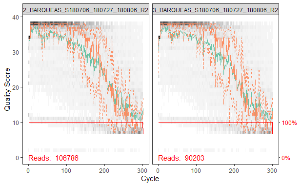

```r
# reverse
plotQualityProfile(fnRs[2:3])
```

- En el eje de las x tenemos el numero de bases que tenemos por secuencia y en el eje de las y tenemos su puntaje de calidad.
- En la escala de grises se ve un heatmap con la frecuencia de cada puntaje en la posicion de cada base.
  - Si en la grafica debe ser entre 30 y 40 en el eje y que es quality score, osea mayor a 30
- La media de los puntajes de calidad en cada posicion se muestra con la linea verde mientras que los cuartiles de la distribucion de los scores se muestran con la linea naranja
- La linea roja muestra la proporcion a escala de las lecturas que se extiende hasta dicha posicion. Esta linea es mas util cuando se usa otras tecnologias de secuenciacion. Dado que estos dados fueron secuenciados usando Illumina todas las lecturas tienen la misma longitud, por eso la linea roja es recta.

Al momento de secuenciar es comun que la calidad de los ultimos nucleotidos secuenciados en cada read siempre sea mas baja. Basados en la linea verde y naranja debemos de decidir donde cortar los ultimos nucleotidos para disminuir el numero de errores que puedan continuar mas adelante en el pipeline.

Sin embargo, es importante notar que esto dependera de la seccion que se mando a secuenciar en el caso de que la seccion sea V3, los cortes de ambos lados pueden ser bastante amplios ya que las superposiciones entre forward y reverse reads es casi total. Sin embargo, otras regiones como V3V4 o V1V2 las secuencias no pueden ser cortadas (o se cortan muy poco) ya que mas adelante en el paso de union de lecturas no va a funcionar ya que las muestras forward y reverse no se van a poder sobrelapar para hacer la union.

**Para ello deben tener amplio conocimiento de la naturaleza de sus muestras y revisar sus graficos de calidad. Sin embargo, prueba y error al momento de la union a veces es inevitable**

ES IMPORTANTE QUE COMO NOSOTROS HAREMOS REPORTES GUARDEMOS LAS FOTOS DE LAS GRAFICAS PARA JUSTIFICAR LO QUE VAYAMOS HACIENDO

# Filtrar y cortar

Primero crearemos una nueva carpeta para nuestras secuencias filtradas, asi como un nombre para los archivos .fastq que obtengamos

La funcion principal para esta seccion es `filterAndTrim()`. El codigo incluira los siguientes parametros:

- Los objetos de Forward and reverse reads
- El camino que acabamos de crear para nuestras forward and reverse reads ya filtradas
- `truncQ= 2` removera lecturas con un score menor o igual a 2
- `maxN=0` removera lecturas que tenga nucleotidos no reconocidos N. Este parametro es necesario ya que el resto del codigo asume que no hay N dentro de las lecturas
- `truncLen` El numero de bases que se van a mantener basados en los graficos de calidad. Si no se incluye este parametro quiere decir que los reads no se van a cortar o truncar. Esto a veces se tiene que hacer cuando se tienen regiones V3V4 que no se superponen lo suficiente para hacer la union
- `maxEE=c(,)` Este es el parametro mas confuso pero se refiere a expected errors o errores esperados. El parametro se requiere como un vector C(#,#) en el cual el primer numero es para las forward reads y el segundo para las reverse. Mientras mas grande el valor, menos estricto es el argumento (Es decir se permite que hayan mas errores esperados). Los valores se seleccionan tambien basados en los graficos de calidad y no necesariamente tienen que ser iguales para ambos sets de lecturas.
- El resto de los parametros se mantienen en sus valores default.

```r
out <- filterAndTrim(fnFs, filtFs, # forward reads
                     fnRs, filtRs, # reverse reads
                     truncLen = c(250,250), # truncado o corte
                     maxN = 0, # remover Ns
                     maxEE = c(5,2), #error esperado
                     truncQ = 2, #quality score
                     rm.phix = TRUE, compress = TRUE, #defaults
                     multithread = FALSE) # en windows
```

```
Creating output directory: C:/Users/cvillalobos/Documents/RStudio/CursoInnovak/Secuenciación/filtered
```

*Especificamente con estas muestras parece que si el proceso de cortado nos evita unir las muestras, vamos a tener que modificar MaxEE y truncQ aa que sea menos estrico para no perder tantas lecturas*

# Tasas de error

A partir de esta seccion el codigo empezara a tardar mas en correr asi que todos los objetos resultados seran guardados como **.Rdata**. Tambien les recomiendo que de rato en rato guarden su notebook solo en caso de que su compu decida que ya se canso. Al guardar los objetos en ese formato solo necesitamos subirlos a nuestro ambiente global si R se cierra y no tenemos que empezar desde cero

Las tasas de error son estimadas hasta que se llegue a una convergencia entre las muestras usando un modelo de error parametrico. El codigo basicamente estima que tan probable es que una base en realidad sea otra (es decir la probabilidad de que haya transiciones) usando la puntuacion de calidad de dicha base. Los objetos generados en este paso se necesitan para hacer la inferencia de muestras.

Como con varios tipos de problemas de machine-learning (aprendizaje automatizado), el algoritmo debe empezar con una suposicion inicial para la cual el numero maximo posible de tasa de error en estos datos se prueba. En este algoritmo esta suposicion es la tasa de error en caso de que la secuencia mas abundante es correcta y el resto son errores.

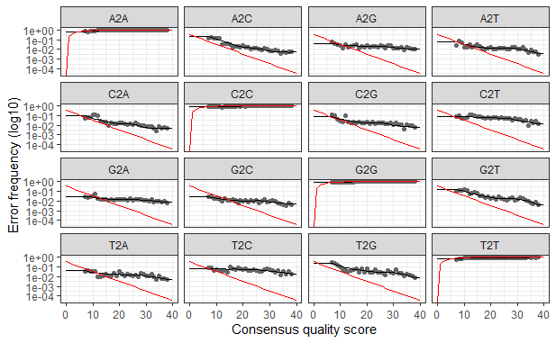

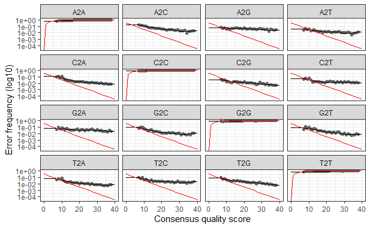

- Los graficos de error muestran las tasas de error para cada posible transicion (A->C, A->G…) Los puntos son las tasas de error observadas para cada puntuacion de calidad.
- La linea negra muestra la tasa de error estimada despues de la convergencia basada en el algortimo de machine-learning
- La linea roja muestra las tasas de error esperadas en la definicion nomina de un Q-score.

**Basicamente se espera que la tasa errores estimada (la linea negra) tenga un buen fit a los puntos o tasas observadas y que las tasas de error disminuyan mientras la calidad se incrementa (linea roja)**

# Inferencia de las muestras

Este es el paso principal de todo el pipeline porque aqui es donde se retiran todos los errores de secuenciacion para dejar unicamente los miembros reales de la comunidad que fue secuenciada. Este codigo usa las lecturas ya filtradas y las tasas de error que acabamos de calcular para eliminar el ruido *(denoise)* nuestras muestras

Este paso ademas incluye de agrupamiento o *pooling*:

- **pool = FALSE** es el default quiere decir que las muestras no se agrupan de ninguna manera. Este default deben de usarlo cuando sus muestras provengan de lugares totalmente diferentes o que en teoria no deberian sobrelapar en sus comunidades bacterianas.
- **pool = TRUE** bajo este parametro todas las muestras se agrupan juntas para la inferencia. Este proceso pueden hacerlo cuando sepan que sus muestras son repeticiones de una misma parcela lugar o tratamiento. Sin embargo, tambien deberan tomar en cuenta el poder de su computadora; de todas las opciones esta es la que mas tarda y mas memoria RAM ocupa ya que hace la inferencia de todas las muestras al mismo tiempo. Por ello dependiendo de su numero de muestras es posible que su computadora no tenga el poder para correr el codigo de esa manera.
- **pool = “pseudo”** En este caso las muestras son procesadas individualmente pero se llevan acabo pasos auto-consistidos *(self consisted steps)* los cuales incrementan la sensibilidad al usar argumentos previos de las otras muestras. Esta es una opcion intermedia ente agrupar o no basados en la velocidad de procesamiento y el numero de quimeras (cuando la agrupacion es verdadera el numero de quimeras se incrementa artificialmente). Usenla si sus muestras estan conectadas de alguna manera (mismo suelo base pero diferente tratamientos por ejemplo)

**Esta es la parte del codigo que tarda mas en correr**

```r
dadaRs_nopool <- dada(filtRs, err=errR, multithread = TRUE,
                      pool = FALSE)
```

```
Sample 1 - 59708 reads in 43428 unique sequences.
Sample 2 - 59201 reads in 42499 unique sequences.
Sample 3 - 52326 reads in 37118 unique sequences.
```

```r
save(dadaRs_nopool, file = "dadaRs_nopool.RData")
```